# HW6

Total points: 100 (5% of final grade).

Due: 11:59 pm, Dec 9th, 2020

## Name: Peter Chang

## Question A (21 pts)

In this question we will apply $K$ nearest neighbor algorithm (KNN) to the prostate cancer data. We will use cross validation to select the best tuning parameter $K$. Then with the optimum $K$, we will evaluate both the training error rate and testing error rate.

### Question A0. Data setup. (0 pts)

If you couldn’t install ElemStatLearn package using CRAN, you may consider the following code:

```r
suppressMessages(library(ElemStatLearn))
suppressMessages(library(class))
prostate_train <- subset(prostate, train)
prostate_test <- subset(prostate, !train)

prostate_train_y <- as.factor(prostate_train$svi)
prostate_train_x0 <- prostate_train[,-match(c("svi", "train"), colnames(prostate_train))]
prostate_train_x <- scale(prostate_train_x0)

prostate_test_y <- as.factor(prostate_test$svi)
prostate_test_x0 <- prostate_test[,-match(c("svi", "train"), colnames(prostate_test))]
prostate_test_x <- scale(prostate_test_x0)
```

For the prostate cancer dataset, we split the data into training dataset and testing dataset according to the **train** variable status. We use the binary variable svi as the outcome variable and lcavol, lweight, age, lbph, lcp, gleason, pgg45, lpsa as features. Each feature is standardized to mean 0 and standard deviation 1 in training dataset and testing dataset respectively. The standardization will guarantee different features are comparable since KNN determines nearest neighbor in terms of Euclidean distance.

### Question A1. 5-folds cross validation to select best tuning parameter. (7 pts)

Within the **training dataset**, perform 5-folds cross validation to select the best tuning parameter $K$. First pre-specify the range of $K$ to be odd number: $K = \{1,3,5,\ldots, 29\}$. Odd $K$ will guarantee there is no tie for the prediction results. For each of these pre-specified $K$, perform 5-folds cross validation and calculate the cross validation error rate. Visualize the curve of $K$ (on x-axis) and cross validation error rate (on y-axis). Mark the point with the minimum cross validation error rate with red color. What is the optimum $K$? Note that if multiple $K$ achieve the same cross validation error rate, choose the smallest $K$ since the classifier is parsimonious. (Another note: here $K$ refers to the number of neighbours in the KNN algorithm. $K$ is not the number of data splitting in the cross-validation. For the cross-validation, number of data splitting is set to be 5.)

```r
## your code
K <- seq(1, 29, 2)

fold <- 5
folds <- cut(seq(1,nrow(prostate_train_x)),breaks=5,labels=FALSE)

EKs <- numeric(fold)
pre <- numeric(length(K))

for (i in K) {
  for (f in 1:fold) {
    #first fold the training data set
    atrain1 <- subset(prostate_train_x, folds != f)
    atest1 <- subset(prostate_train_x, folds == f)

    alabel_train <- subset(prostate_train_y, folds != f)
    alabel_test <- subset(prostate_train_y, folds == f)

    #then fit via KNN
    knnFit <- knn(atrain1, atest1, alabel_train, k=i)

    knnTable <- table(knnFit, truth=alabel_test)

    #get prediction rates from folds
    EKs[f] <- 1 - sum(diag(knnTable))/sum(knnTable)

    #gets final prediction rates via mean
    pre[i] <- mean(EKs)
  }
}

pre <- pre[seq(1, length(pre), 2)] #for some reason contains even numbered values so need to remove those
pre
```

```
##  [1] 0.1802198 0.1494505 0.1648352 0.1648352 0.1483516 0.1747253 0.2054945
##  [8] 0.1901099 0.2054945 0.2054945 0.2208791 0.2208791 0.2208791 0.2208791
## [15] 0.2208791
```

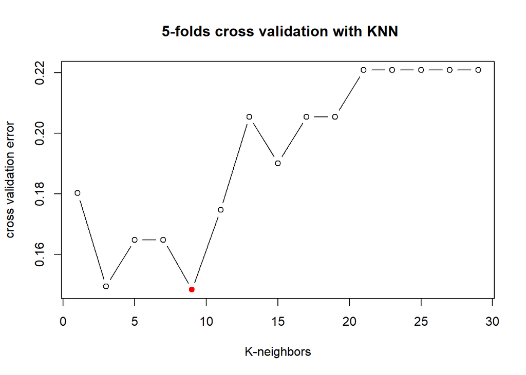

```r
cvknn <- as.data.frame(cbind(K, pre))

plot(x = cvknn$K, y = cvknn$pre,
     main = ' 5-folds cross validation with KNN',
     xlab = 'K-neighbors', ylab = 'cross validation error',
     type = 'b')
points(cvknn$K[pre == min(cvknn$pre)], min(cvknn$pre), col = 'red', pch = 19)
```

```r
cvknn[which.min(cvknn$pre),] #gives us value of optimum K with minimum cross validation error
```

```
##   K       pre
## 5 9 0.1483516
```

### Question A2. leave one out cross validation to select best tuning parameter. (7 pts)

Within the **training dataset**, perform leave one out cross validation to select the best tuning parameter $K$. First pre-specify the range of $K$ to be odd number: $K = \{1,3,5,\ldots, 29\}$. Odd $K$ will guarantee there is no tie for the prediction results. For each of these pre-specified $K$, perform leave one out cross validation and calculate the cross validation error rate. Visualize the curve of $K$ (on x-axis) and cross validation error rate (on y-axis). Mark the point with the minimum cross validation error rate with red color. What is the optimum $K$? Note that if multiple $K$ achieve the same cross validation error rate, choose the smallest $K$ since the resulting classifier is parsimonious.

```r
## your code
n <- nrow(prostate_train_x)

EKs <- numeric(n)

for (i in K) {
  for (f in 1:n) {
    #first fold the training data set
    atrain1 <- prostate_train_x[-f,]
    atest1 <- prostate_train_x[f,]

    alabel_train <- prostate_train_y[-f]
    alabel_test <- prostate_train_y[f]

    #then fit via KNN
    knnFit <- knn(atrain1, atest1, alabel_train, k=i)

    knnTable <- table(knnFit, truth=alabel_test)

    #get prediction rates from folds
    EKs[f] <- 1 - sum(diag(knnTable))/sum(knnTable)

    #gets final prediction rates via mean
    pre[i] <- mean(EKs)
  }
}

pre <- pre[seq(1, length(pre), 2)] #for some reason contains even numbered values so need to remove those
pre
```

```
##  [1] 0.13432836 0.13432836 0.13432836 0.10447761 0.08955224 0.08955224
##  [7] 0.11940299 0.08955224 0.11940299 0.13432836 0.13432836 0.19402985
## [13] 0.23880597 0.22388060 0.22388060
```

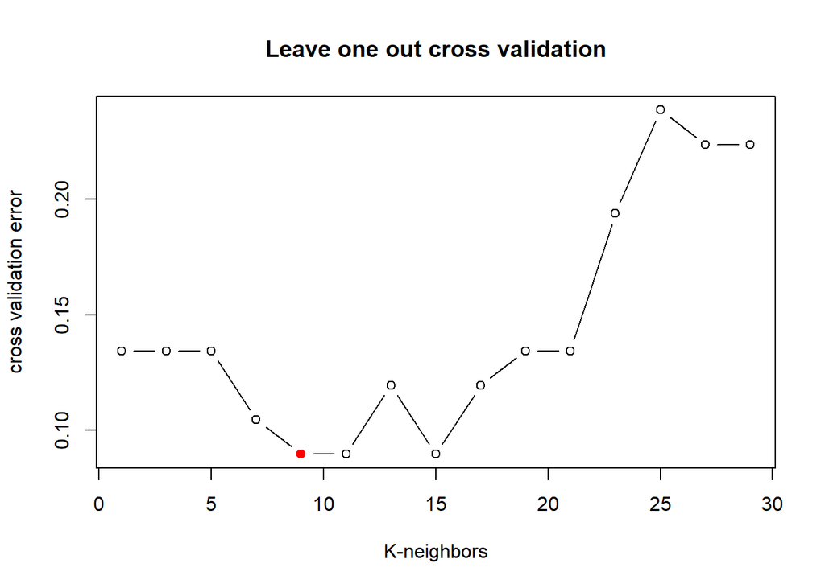

```r
cvknn2 <- as.data.frame(cbind(K, pre))

plot(x = cvknn2$K, y = cvknn2$pre,
     main = 'Leave one out cross validation',
     xlab = 'K-neighbors', ylab = 'cross validation error',
     type = 'b')
points(min(cvknn2$K[pre == min(cvknn2$pre)]), min(cvknn2$pre), col = 'red', pch = 19)
```

```r
cvknn2[which.min(cvknn2$pre),]#gives us value of optimum K with minimum cross validation error
```

```
##   K        pre
## 5 9 0.08955224
```

### Question A3. Evaluate the training error rate and testing error rate. (7 pts)

Using the optimum $K$ from either **Step 1** or **Step 2** to build a KNN classifier using the whole training dataset. What is the mis-classification error rate for the training data? Also predict the testing dataset, what the mis-classification error rate for the testing data? Which one is smaller?

```r
knnFit <- knn(prostate_train_x, prostate_test_x, prostate_train_y, k=9)

knnTable <- table(knnFit, truth=prostate_test_y)

1 - sum(diag(knnTable))/sum(knnTable) #misclassification error rate for the training data
```

```
## [1] 0.1666667
```

```r
knnFit2 <- knn(prostate_test_x, prostate_train_x, prostate_test_y, k=9)

knnTable2 <- table(knnFit2, truth=prostate_train_y)

1 - sum(diag(knnTable2))/sum(knnTable2) #misclassification error rate for the testing data
```

```
## [1] 0.1791045
```

The missclassification error rate of the training data is smaller.

## Question B (21 pts)

This description is from https://en.wikipedia.org/wiki/RMS_Titanic. Titanic was a British passenger liner that sank in the North Atlantic Ocean in the early morning hours of 15 April 1912, after it collided with an iceberg during its maiden voyage from Southampton to New York City. There were an estimated 2,224 passengers and crew aboard the ship, and more than 1,500 died, making it one of the deadliest commercial peacetime maritime disasters in modern history. Now we will work on the Titanic data and predict passenger’s survival.

### Question B0, data setup. (0 pts)

The Titanic data in available in R package titanic. The outcome variable is Survived (Passenger Survival Indicator), with 1 indicating survived and 0 indicating died. Other predictors includes:

- Pclass: Passenger Class, 1,2,3
- Sex: female or male
- Age: Age
- SibSp: Number of Siblings/Spouses Aboard
- Parch: Number of Parents/Children Aboard
- Fare: Passenger Fare

We first convert Survived, Pclass and Sex as factors. Then we impute the missing value by rfImpute (so random forest can also be used to impute missing data). We randomly split the data as training data (2/3) and testing data (1/3). The training data is in variable data_train; The testing data is in variable data_test.

```r
library(titanic)
library(rpart)
library(rpart.plot)
suppressMessages(library(randomForest))

dim(titanic_train)
```

```
## [1] 891  12
```

```r
titanic_train$Survived <- as.factor(titanic_train$Survived)
titanic_train$Pclass <- as.factor(titanic_train$Pclass)
titanic_train$Sex <- as.factor(titanic_train$Sex)

set.seed(32611)
titanic <- rfImpute(x = titanic_train[,c("Pclass", "Sex", "Age",
                                         "SibSp", "Parch", "Fare")], y = titanic_train$Survived)
```

```
## ntree      OOB      1      2
##   300:  17.17%  9.65% 29.24%
## ntree      OOB      1      2
##   300:  17.28% 10.20% 28.65%
## ntree      OOB      1      2
##   300:  17.06%  9.11% 29.82%
## ntree      OOB      1      2
##   300:  17.40% 10.56% 28.36%
## ntree      OOB      1      2
##   300:  16.95% 10.02% 28.07%
```

```r
names(titanic)[1] <- "Survived"

set.seed(32611)
trainIndex <- sample(nrow(titanic), round(nrow(titanic)*2/3))
testIndex <- setdiff(1:nrow(titanic_train), trainIndex)

data_train <- titanic[trainIndex,]
data_test <- titanic[testIndex,]
```

### Question B1, fit the CART model. (5 pts)

Fit a CART model on the training data using Survived as outcome variable and Pclass, Sex, Age, SibSp, Parch, Fare as predictors. Visualize the decision tree outputted by CART model.

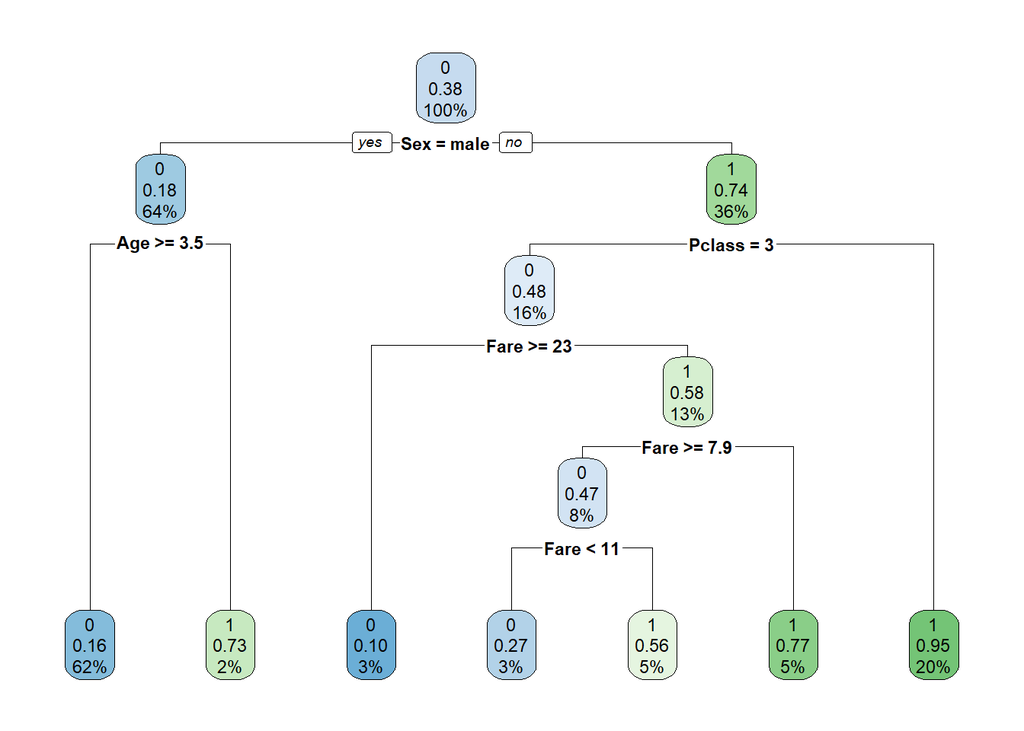

```r
## your code
cartfit <- rpart(Survived ~ ., data = data_train)

rpart.plot(cartfit)
```

### Question B2, predict the testing dataset using the CART model. (2 pts)

Print out the 2 by 2 confusion table for the testing set (predicted survival status by actual survival status). What is the prediction accuracy for CART?

```r
## your code
predcart <- predict(object = cartfit, newdata = data_test)

atable <- table(predictLabel = predcart[,"1"]>0.5, trueLabel = data_test$Survived)

atable #2x2 confusion table
```

```
##             trueLabel
## predictLabel   0   1
##        FALSE 165  41
##        TRUE   15  76
```

```r
sum(diag(atable))/sum(atable) #prediction accuracy
```

```
## [1] 0.8114478
```

The prediction accuracy for CART is 81.1%.

### Question B3, fit the random forest model. (5 pts)

Fit the random forest model on the training data using Survived as outcome variable and Pclass, Sex, Age, SibSp, Parch, Fare as predictors. Visualize the importance score of all predictors.

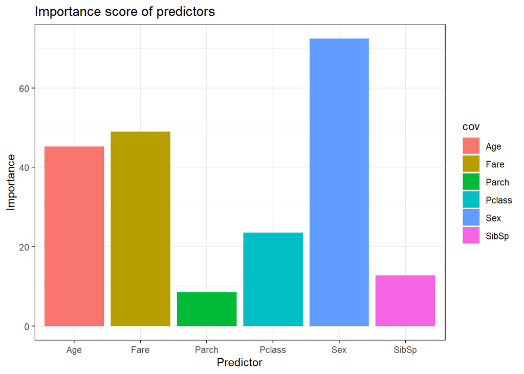

```r
## your code
rffit <- randomForest(Survived ~ ., data = data_train)

imscore <- importance(rffit)
imData <- data.frame(cov = rownames(imscore), importance = imscore[,1])

ggplot(imData) + aes(x = cov, y = importance, fill = cov) + geom_bar(stat = 'identity') + theme_bw() + labs(title = "Importance score of predictors", x = 'Predictor', y = 'Importance')
```

### Question B4, predict the testing dataset using the random forest model. (2 pts)

Print out the 2 by 2 confusion table. What is the prediction accuracy for random forest?

```r
## your code
predrf <- predict(rffit, data_test)

conf <- table(predrf, trueLabel = data_test$Survived)
conf #2x2 confusion table
```

```
##       trueLabel
## predrf   0   1
##      0 162  37
##      1  18  80
```

```r
sum(diag(conf))/sum(conf) #accuracy
```

```
## [1] 0.8148148
```

The prediction accuracy of random forest is 81.4%.

### Question B5, also apply SVM (linear kernal), SVM (Gaussian kernal), LDA, KNN (K=5). (7 pts)

Compare all these 6 classifiers (also include CART and random forest). Which one is the best classifier in terms of prediction accuracy in the testing dataset. (Hint: For simplicity, we do not scale the original data to mean 0 or standard deviation 1. For KNN, you may want to convert sex to a binary variable [0/1], and Pclass to continuous. )

Making a table for future use:

```r
## your code
comparison <- data.frame(Classifier = c("CART", "Random Forest", "SVM (linear)", "SVM (Gaussian)", "LDA", "KNN (K = 5)"),
                         'Prediction accuracy' = rep(NA,6))


comparison[1,2] <- sum(diag(atable))/sum(atable)
comparison[2,2] <- sum(diag(conf))/sum(conf)
```

Now to start predicting with the classifiers:

```r
#SVM (linear kernal)
svml <- svm(Survived ~ ., data = data_train, kernel = 'linear')

predsvml <- predict(svml, data_test)

conf2 <- table(predsvml, trueLabel = data_test$Survived)
conf2 #2x2 confusion table
```

```
##         trueLabel
## predsvml   0   1
##        0 158  42
##        1  22  75
```

```r
comparison[3,2] <- sum(diag(conf2))/sum(conf2) #accuracy

#SVM (gaussian kernal)
svmg <- svm(Survived ~ . ,data=data_train, kernel = "radial")

predsvmg <- predict(svmg, data_test)

conf3 <- table(predsvmg, trueLabel = data_test$Survived)
conf3 #2x2 confusion table
```

```
##         trueLabel
## predsvmg   0   1
##        0 162  41
##        1  18  76
```

```r
comparison[4,2] <- sum(diag(conf3))/sum(conf3) #accuracy

#LDA
ldafit <- lda(Survived ~ ., data = data_train)
pred_lda <- predict(ldafit, data_test)$class

conf4 <- table(pred_lda, trueLabel = data_test$Survived)
conf4 #2x2 confusion table
```

```
##         trueLabel
## pred_lda   0   1
##        0 157  44
##        1  23  73
```

```r
comparison[5,2] <- sum(diag(conf4))/sum(conf4)

#KNN (K=5)
##Convert sex to a binary variable [0/1], and Pclass to continuous.

data_train2 <- data_train
data_test2 <- data_test

data_train2 <- data_train2 %>% mutate(Sex =ifelse(data_train2$Sex == 'male', 1, 0))
data_train2$Pclass <- as.numeric(data_train2$Pclass)

data_test2 <- data_test2 %>% mutate(Sex =ifelse(data_test2$Sex == 'male', 1, 0))
data_test2$Pclass <- as.numeric(data_test2$Pclass)

adata_train <- data_train2[,-1]
adata_test <- data_test2[,-1]

alabel_train <- data_train2[,1]
alabel_test <- data_test2[,1]

knnFit <- knn(adata_train, adata_test, alabel_train, k=5)

knnTable <- table(knnFit, truth=alabel_test)
knnTable
```

```
##       truth
## knnFit   0   1
##      0 146  48
##      1  34  69
```

```r
comparison[6,2] <- sum(diag(knnTable))/sum(knnTable)
```

Here is a table of the classifiers and their prediction accuracy. I’ve also included which classifier had the highest prediction accuracy.

```r
comparison
```

```
##       Classifier Prediction.accuracy
## 1           CART           0.8114478
## 2  Random Forest           0.8148148
## 3   SVM (linear)           0.7845118
## 4 SVM (Gaussian)           0.8013468
## 5            LDA           0.7744108
## 6    KNN (K = 5)           0.7239057
```

```r
comparison[which.max(comparison$Prediction.accuracy),]
```

```
##      Classifier Prediction.accuracy
## 2 Random Forest           0.8148148
```

## Question C (24 pts)

In this question we will implement importance sampling and compare the performance with regular sampling algorithm. The goal is to estimate $P(Y \ge 3)$ where $Y \sim N(0,1)$. The underlying truth is 0.0013499, which can be estimated by $P(Y>3) = \int_3^\infty \frac{1}{2\pi} \exp(-\frac{t^2}{2}) dt$. In fact,
$$P(Y>3) = \int_3^\infty \frac{1}{\sqrt{2\pi}} \exp(-\frac{t^2}{2}) dt = \int_{-\infty}^\infty h(t)\frac{1}{\sqrt{2\pi}} \exp(-\frac{t^2}{2}) dt,$$
where $h(t) = 1$ if $t>3$ and $h(t) = 0$ if $t\ \le 3$.

### Question C1. Calculate $P(Y>3)$ using integrate function (6 pts)

```r
## your code
PY3 <- function(t) (1/sqrt(2*pi))*exp(-(t^2)/2)
ht <- function(t) ifelse(t > 3, 1, 0)
ep <- function(x) ht(x)*PY3(x)

truth <- integrate(f = ep, lower = 3, upper = Inf)$value

truth
```

```
## [1] 0.001349899
```

### Question C2. Direct sampling (6 pts)

Draw $N=10,000$ iid samples $Y_1, \ldots, Y_{10,000}$ from N(0,1). An estimator for $P(Y>3)$ is $\hat{I}_1 = \frac{1}{N}\sum_{i=1}^N h(Y_i)$. Perform one time simulation and what is your $\hat{I}_1$?

```r
## your code
set.seed(123)
dsamp <- rnorm(10000, 0, 1)

mean(ht(dsamp))
```

```
## [1] 0.0015
```

### Question C3. Imporatance sampling (6 pts)

Draw $N=10,000$ iid samples $Y_1, \ldots, Y_{10000}$ from $N(3,2^2)$. Denote $\hat{I}_2$ is the estimator of $P(Y>3)$ using this importance sampling. Perform one time simulation and what is your $\hat{I}_2$?

```r
## your code
set.seed(123)

q.r <- function(x) {rnorm(x, 3, 2^2)}
q.d <- function(x) {dnorm(x, 3, 2^2)}

N <- 10000

x.m <- q.r(N)

ww <- PY3(x.m)/q.d(x.m)

qq <- ww/sum(ww)

x.g <- ht(x.m)

sum(x.g * qq)
```

```
## [1] 0.001327111
```

### Question C4. Compare $\hat{I}_1$ and $\hat{I}_2$. (6 pts)

Repeat these simulations for $\hat{I}_1$ and $\hat{I}_2$ $B = 1,000$ times respectively. What are the bias of these two estimators? What are the variance of these two estimators? What are the MSE of these two estimators? Which one is better?

```r
## your code
B <- 1000
n <- 10000

Ts <- matrix(0, nrow = B, ncol = 2)

colnames(Ts) <- c("I1", "I2")

for (b in 1:B) {
  set.seed(b)
  x <- rnorm(n, 0, 1) #direct
  y <- rnorm(n, 3, 4) #importance

  #direct sampling

  Ts[b, 1] <- mean(ht(x))

  #importance sampling
  q.r <- function(x) {rnorm(x, 3, 2^2)}
  q.d <- function(x) {dnorm(x, 3, 2^2)}

  x.m <- q.r(n)

  ww <- PY3(x.m)/q.d(x.m)

  qq <- ww/sum(ww)

  x.g <- ht(x.m)

  Ts[b, 2] <- sum(x.g * qq)

}

bias1 <- abs(mean(Ts[,1]) - truth)
bias2 <- abs(mean(Ts[,2]) - truth)

bias <- c(bias1, bias2)
vars <- apply(Ts, 2, var)
MSE <- bias^2 + vars

comparisonTable <- rbind(bias, vars, MSE)
colnames(comparisonTable) <- c("I1", "I2")
comparisonTable
```

```
##                I1           I2
## bias 4.898737e-06 2.913607e-07
## vars 1.520871e-07 3.897904e-09
## MSE  1.521111e-07 3.897988e-09
```

The bias, variance, and MSE of $\hat{I}_2$ is smaller than $\hat{I}_1$, so importance sampling is preferred.

## Question D (30 pts)

Assume we have one observation $X \sim Binomial(n, \theta)$ (i.e. $f(x | \theta) = \binom{n}{x}\theta^{x} (1 - \theta)^{n-x}$). The prior for $\theta$ is $\pi(\theta) \sim Beta(a,b)$. By Bayes rules, we can derive
$$p(\theta|x) \propto f(x | \theta) \pi(\theta) = \theta^{x} (1 - \theta)^{n-x} \theta^{a - 1} (1 - \theta)^{b - 1} = \theta^{x+a-1} (1 - \theta)^{n-x+b-1}$$
So the posterior density function for $\theta$ $p(\theta|x) \sim Beta(x+a,b+n-x)$.

### Question D1. implement Gibbs sampling (5 pts)

Set $a=b=2$, $n=10$. Initialize $x=5$ and $\theta = 0.5$. Implement Gibbs sampling algorithm by iteratively updating $x$ and $\theta$ (number of samples $B = 1,000$). Visualize the time series plot of $\theta$.

```r
## your code
set.seed(123)

#prior parameters
a = 2
b = 2
n = 10

#starting values
x = 5
theta = .5

#Gibbs
B = 1000
draws = matrix(0, B, 2)
draws[1,] = c(x, theta)
colnames(draws) =  c('x', 'theta')

for(i in 2:B) {
  x = rbinom(1, size = n, prob=theta)
  theta = rbeta(1, a + x, b + n - x)

  draws[i,] <- c(x, theta)
}
```

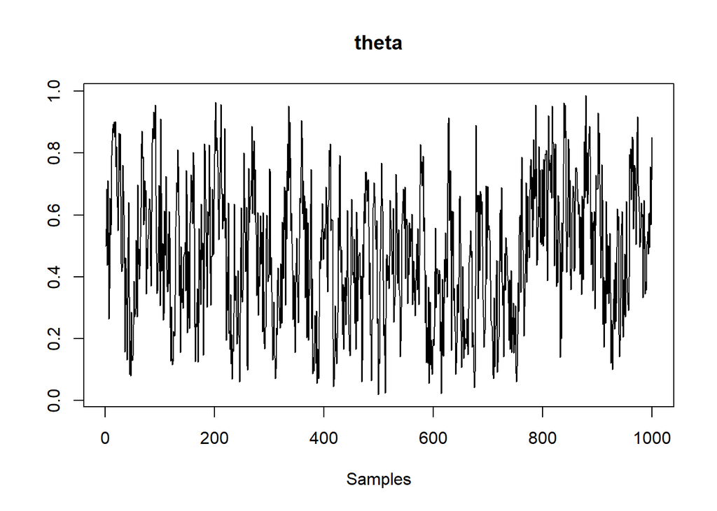

```r
ts.plot(draws[, 2], xlab = 'Samples', ylab = '', main = 'theta')
```

### Question D2. Use samples from Gibbs sampling. (5 pts)

Decide a reasonable burnin period cutoff and remove these samples first. Draw the histogram of $\theta$ from Gibbs sampling. What is the posterior median of $\theta$ from Gibbs sampling?

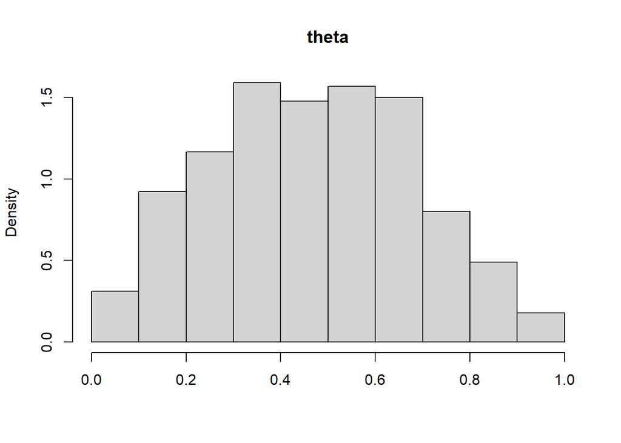

```r
## your code
hist(draws[101:1000,2],prob=T,main="theta",xlab="")
```

```r
median(draws[101:1000,2]) #posterior median
```

```
## [1] 0.4688503
```

### Question D3. auto correlation for gibbs sampling. (5 pts)

Draw the auto correlation plot (x-axis is lag and y-axis is Auto correlation (ACF)). What is the effective sample size?

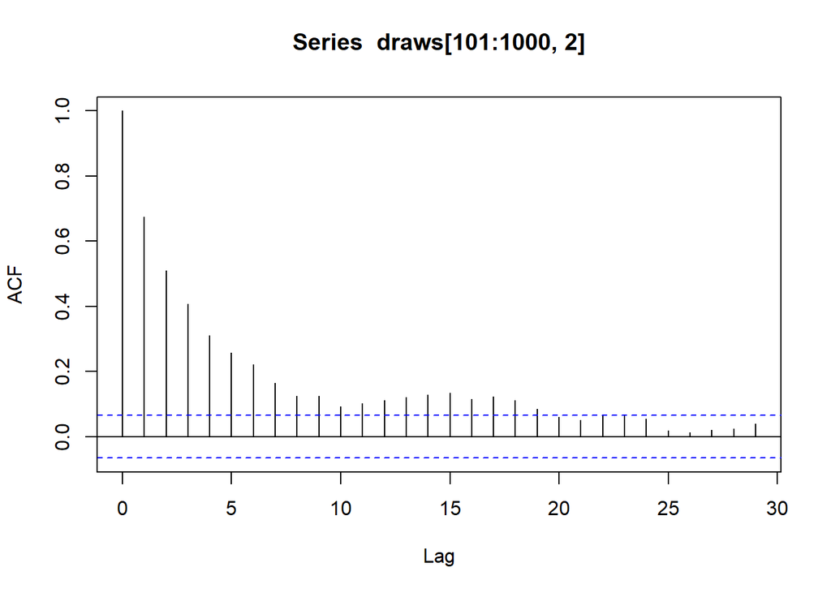

```r
## your code
acf(draws[101:1000, 2])
```

```r
rx1 <- acf(draws[101:1000, 2], plot = FALSE)[1] #this will give us first order AC for SSIF

ssif <- as.numeric((1 + rx1[["acf"]])/(1 - rx1[["acf"]]))

900/ssif #gives us effect sample size
```

```
## [1] 175.2407
```

### Question D4. implement MH algorithm (5 pts)

We still draw x from $X \sim Binomial(n, \theta)$ (i.e. $f(x | \theta) = \binom{n}{x}\theta^{x} (1 - \theta)^{n-x}$). For $\theta$, instead of directly draw $\theta$ from the posterior density function (i.e., $p(\theta|x) \sim Beta(x+a,b+n-x)$), we will using MH algorithm to get samples. Suppose the sampler distribution is Gaussian distribution $\theta' \sim N(\theta, 0.2^2)$, where $\theta$ is current step value and $\theta'$ is the next step value. Again initialize $\theta = 0.5$, and $X = 5$. Set $a=b=2$, $n=10$. Repeat MH algorithm $B = 1,000$ times to iteratively update $\theta$ and $x$. Visualize the time series plot of $\theta$. What is the percentage of times a new proposed $\theta$ is accepted?

```r
## your code
set.seed(123)

#prior parameters
a = 2
b = 2
n = 10

#target distribution
p <- function(y) {((y)^(x+a-1))*((1-y)^(n-x+b-1))}

#starting values
x = 5
theta = .5

#sampler starting value
std <- .2^2

B <- 1000
accepted <- 0 #accepted proposals
u <- runif(B)

draws2 = matrix(0, B, 2)
draws2[1,] = c(x, theta)
colnames(draws2) =  c('x','theta')

for (i in 2:B) {
  #drawing theta
  draws2[i, 1] <- rbinom(1, size = n, prob = theta)

  thetap <- rnorm(1, mean = theta, sd = std)

  alpha <- min(1,
           (p(thetap)/p(theta))*(dnorm(theta, thetap, sd = 1)/dnorm(thetap, theta, sd = 1)))

  draws2[i, 2] <- theta <- ifelse(u[i] < alpha, thetap, theta)

  accepted <- accepted + (u[i] < alpha)
}


accepted/B #percentage when the proposed theta was accepted
```

```
## [1] 0.901
```

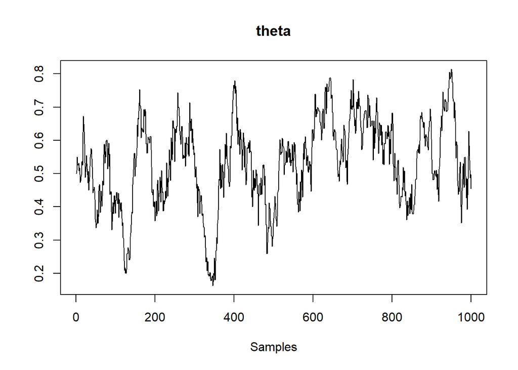

```r
ts.plot(draws2[,2], xlab = 'Samples', ylab = '', main = 'theta')
```

### Question D5. auto correlation for MH. (5 pts)

Determine a reasonable burnin period and remove the burnin samples. Draw the auto correlation plot (x-axis is lag and y-axis is Auto correlation (ACF)). What is the effective sample size?

This one is a little bit more unclear on what the burnin period should be, but I think I will again use 100.

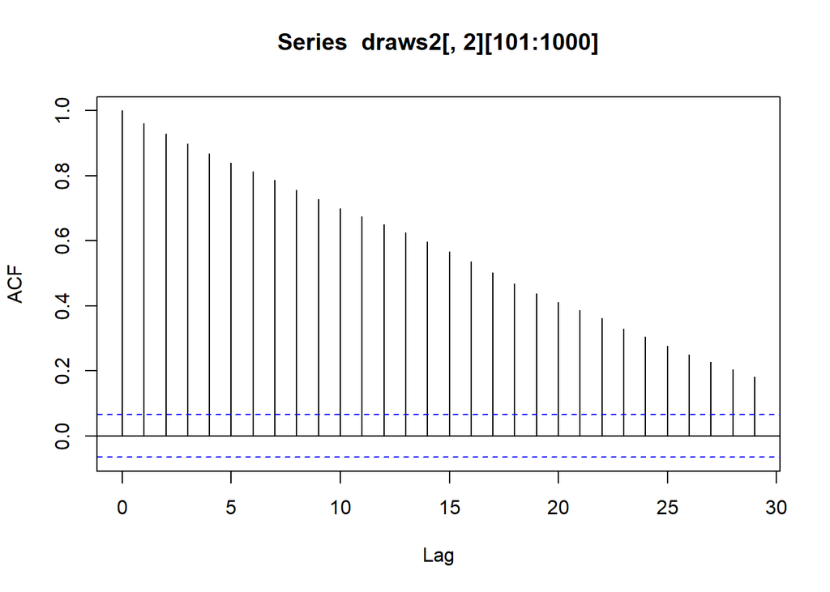

```r
## your code
acf(draws2[,2][101:1000])
```

```r
rx12 <- acf(draws2[,2][101:1000], plot = FALSE)[1] #this will give us first order AC for SSIF

ssif2 <- as.numeric((1 + rx12[["acf"]])/(1 - rx12[["acf"]]))

900/ssif2 #gives us effect sample size
```

```
## [1] 17.80383
```

### Question D6. Compare empirical CDFs (from both MH and Gibbs) and theoritical CDF. (5 pts)

Visualize these two the empirical CDFs and the theoretical CDF of $\theta$ (i.e., CDF from the posterior density function) in the same figure.

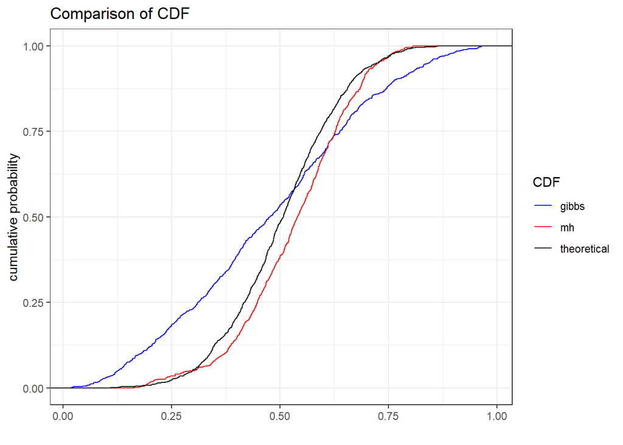

```r
## your code
set.seed(123)
D6 <- as.data.frame(cbind(gibbs = draws[,2],mh = draws2[,2], theoretical = rbeta(1000, a + x, b + n - x)))

colors <- c('gibbs' = "blue", 'mh' = "red", 'theoretical' = "black")

D6 %>% ggplot() + stat_ecdf(aes(gibbs, color = 'gibbs')) + stat_ecdf(aes(mh , color = 'mh')) + stat_ecdf(aes(theoretical, color = 'theoretical')) + theme_bw() + labs(title = "Comparison of CDF", x = '', y = 'cumulative probability', color = "CDF") + scale_color_manual(values = colors)
```

Looks like the CDF of the Metropolis-Hastings algorithm follows more closely to the CDF of the theoretical CDF than the Gibbs sampling algorithm.

## Note (4 pts):

### Homework should be uploaded to courseweb:

1. Don’t forget to write your name in this HW (E.g., Name:XXX).
2. Save your compiled result as html file. Rename the file name as: hw6_Lastname_Firstname.html.
3. Don’t forget to write your name on the top of the html file.
4. RMD file is not required. You only need to upload the html file to the [e-leaning](https://elearning.ufl.edu) website.

### If you generate a figure, please write appropriate figure title, labels, legend if necessary.

### If your code is not intuitive, please write comments to make the code readible.